# Models with text features

ivan Flores

5/9/2021

## Advanced Business Analytics Group Project

*Group Members:*

1. Ivan Flores Martinez
2. Ellijah Ellison
3. Tristan Richard
4. Bailey Brown
5. Ryon Ripper

## Intro

Airbnb has become increasingly popular among travelers for accommodation across the world. Accordingly, there are large datasets being collected from the Airbnb listings with rich features. In this project, we aim to predict Airbnb listing price in Asheville with various machine learning approaches.

### Load the complete dataset for Ashville

```r
library(readxl)
Airbnb_asheville_merged <- read_excel("Airbnb_asheville_merged.xlsx")
head(Airbnb_asheville_merged)
```

```
## # A tibble: 6 x 20
##   room_id host_id room_type    borough neighborhood reviews overall_satisfaction
##     <dbl>   <dbl> <chr>        <lgl>   <chr>          <dbl>                <dbl>
## 1   67870  335286 Private room NA      Asheville        164                    5
## 2   67870  335286 Private room NA      Asheville        170                    5
## 3   67870  335286 Private room NA      Asheville        172                    5
## 4   67870  335286 Private room NA      Asheville        176                    5
## 5   67870  335286 Private room NA      Asheville        176                    5
## 6   67870  335286 Private room NA      Asheville        177                    5
## # … with 13 more variables: accommodates <dbl>, bedrooms <dbl>, price <dbl>,
## #   minstay <dbl>, last_modified <chr>, latitude <dbl>, longitude <dbl>,
## #   survey_id <dbl>, country <lgl>, city <chr>, bathrooms <lgl>, name <chr>,
## #   location <chr>
```

```r
# Rename the database
asheville <- Airbnb_asheville_merged
```

Features are chosen only if they are informative and are likely to correlated with the listing’s price. Therefore, we eliminated features like id and host id, which appear to be noise, features like location and country, where the majority of the data take the same value, and features like minstay, where the majority of the data are null.

```r
#remove variables
library (dplyr)
asheville <- asheville %>% select(-c(borough))
asheville <- asheville %>% select(-c(minstay))
asheville <- asheville %>% select(-c(country))
asheville <- asheville %>% select(-c(bathrooms))
asheville <- asheville %>% select(-c(survey_id))
asheville <- asheville %>% select(-c(name))
asheville <- asheville %>% select(-c(location))
asheville <- asheville %>% select(-c(city))
```

We removed duplicate listings in the dataset.

```r
#dataset with each unique listing
asheville_newest <- asheville %>%
  arrange(room_id, desc(last_modified)) %>%
  distinct(room_id, .keep_all = TRUE)
```

We identified missing values in the dataset and impute the missings values with the mean.

```r
# Count missing values in variables
sum(is.na(asheville_newest$overall_satisfaction))
```

```
## [1] 36
```

```r
sum(is.na(asheville_newest$reviews))
```

```
## [1] 0
```

```r
sum(is.na(asheville_newest$accommodates))
```

```
## [1] 0
```

```r
sum(is.na(asheville_newest$bedrooms))
```

```
## [1] 0
```

```r
sum(is.na(asheville_newest$price))
```

```
## [1] 0
```

```r
sum(is.na(asheville_newest$latitude))
```

```
## [1] 0
```

```r
sum(is.na(asheville_newest$longitude))
```

```
## [1] 0
```

```r
# Impute the missing values in overall satisfaction
asheville_newest$overall_satisfaction[is.na(asheville_newest$overall_satisfaction)] <- mean(asheville_newest$overall_satisfaction, na.rm = TRUE)

sum(is.na(asheville_newest$overall_satisfaction))
```

```
## [1] 0
```

We created a new variable using the current latitude and longitude variables which calculates the distance of each listing from a central point in downtime Ashville.

```r
# Create reference point data
library(sf)
library(data.table)
point <- data_frame(mylon = -82.5540, mylat = 35.5946)
# Specify the source of X and Y coordinates
point_sf <- st_as_sf(point, coords = c("mylon", "mylat"))

# Set the projection to EPSG 4326 (long-lat)
st_crs(point_sf) <- 4326

#create target point data
target <- asheville_newest %>% select(room_id, longitude, latitude)

# Convert data.frame to data.table
setDT(target)

class(target)
```

```
## [1] "data.table" "data.frame"
```

```r
# Specify the source of X and Y coordinates
target_sf <- st_as_sf(target, coords = c("longitude", "latitude"))

# Set the projection to EPSG 4326 (long-lat)
st_crs(target_sf) <- 4326

# Calculate the distance
##distance is in Meters
target_sf2 <- target_sf %>%
  mutate(Dist = as.numeric(st_distance(point_sf, target_sf, by_element = TRUE)))
target_sf2
```

```
## Simple feature collection with 1313 features and 2 fields
## Geometry type: POINT
## Dimension:     XY
## Bounding box:  xmin: -82.68362 ymin: 35.46794 xmax: -82.46119 ymax: 35.65384
## Geodetic CRS:  WGS 84
## First 10 features:
##    room_id                   geometry      Dist
## 1    67870  POINT (-82.6263 35.55371) 7970.7541
## 2    80331 POINT (-82.54972 35.56915) 2850.2941
## 3    80905 POINT (-82.55237 35.59701)  305.0920
## 4    86981 POINT (-82.54912 35.58656)  995.3072
## 5    86983 POINT (-82.55093 35.58674)  915.4083
## 6    86984 POINT (-82.55039 35.58664)  941.8142
## 7   136547 POINT (-82.60732 35.57744) 5193.7691
## 8   151444 POINT (-82.56832 35.60474) 1717.4569
## 9   155305 POINT (-82.59617 35.57972) 4163.3386
## 10  156805 POINT (-82.59697 35.57755) 4329.4212
```

```r
#add distance to orig. df
Asheville_new <- asheville %>%
  inner_join(target_sf2 , by = "room_id")

#add distance to new df
Asheville_new_modified <- asheville_newest %>%
  inner_join(target_sf2, by = "room_id")

str(Asheville_new_modified)
```

```
## tibble[,14] [1,313 × 14] (S3: tbl_df/tbl/data.frame)
##  $ room_id             : num [1:1313] 67870 80331 80905 86981 86983 ...
##  $ host_id             : num [1:1313] 335286 433914 427027 1675743 1675743 ...
##  $ room_type           : chr [1:1313] "Private room" "Private room" "Entire home/apt" "Private room" ...
##  $ neighborhood        : chr [1:1313] "Asheville" "Asheville" "Asheville" "Asheville" ...
##  $ reviews             : num [1:1313] 178 57 67 44 22 30 46 32 128 35 ...
##  $ overall_satisfaction: num [1:1313] 5 5 5 5 4.5 4.5 4.5 5 4.5 4.5 ...
##  $ accommodates        : num [1:1313] 2 2 10 2 12 4 4 3 3 2 ...
##  $ bedrooms            : num [1:1313] 1 1 2 1 4 1 2 1 1 1 ...
##  $ price               : num [1:1313] 80 125 190 90 525 100 120 85 100 65 ...
##  $ last_modified       : chr [1:1313] "2017-07-20 02:53:24.471794" "2017-07-20 02:53:42.815688" "2017-07-20 02:55:55.976193" "2016-09-10 23:26:14.250365" ...
##  $ latitude            : num [1:1313] 35.6 35.6 35.6 35.6 35.6 ...
##  $ longitude           : num [1:1313] -82.6 -82.5 -82.6 -82.5 -82.6 ...
##  $ geometry            :sfc_POINT of length 1313; first list element:  'XY' num [1:2] -82.6 35.6
##  $ Dist                : num [1:1313] 7971 2850 305 995 915 ...
```

```r
#remove unnecessary variable
Asheville_new_modified <- Asheville_new_modified %>% select(-c(geometry))
```

We create PCAs for highly correlated variables.

```r
# Correlate the variables
cor(Asheville_new_modified$bedrooms, Asheville_new_modified$accommodates)
```

```
## [1] 0.8123258
```

```r
head(Asheville_new_modified)
```

```
## # A tibble: 6 x 13
##   room_id host_id room_type   neighborhood reviews overall_satisfa… accommodates
##     <dbl>   <dbl> <chr>       <chr>          <dbl>            <dbl>        <dbl>
## 1   67870  335286 Private ro… Asheville        178              5              2
## 2   80331  433914 Private ro… Asheville         57              5              2
## 3   80905  427027 Entire hom… Asheville         67              5             10
## 4   86981 1675743 Private ro… Asheville         44              5              2
## 5   86983 1675743 Entire hom… Asheville         22              4.5           12
## 6   86984 1675743 Private ro… Asheville         30              4.5            4
## # … with 6 more variables: bedrooms <dbl>, price <dbl>, last_modified <chr>,
## #   latitude <dbl>, longitude <dbl>, Dist <dbl>
```

```r
# Create database for pca
pca_data <- Asheville_new_modified[,c(7:9)]
pca <- prcomp(pca_data,center=TRUE,scale. = TRUE)
print(pca)
```

```
## Standard deviations (1, .., p=3):
## [1] 1.5018403 0.7463339 0.4329681
##
## Rotation (n x k) = (3 x 3):
##                    PC1        PC2         PC3
## accommodates 0.6061539 -0.3775789  0.70000829
## bedrooms     0.6096479 -0.3446643 -0.71381787
## price        0.5107904  0.8594421  0.02127058
```

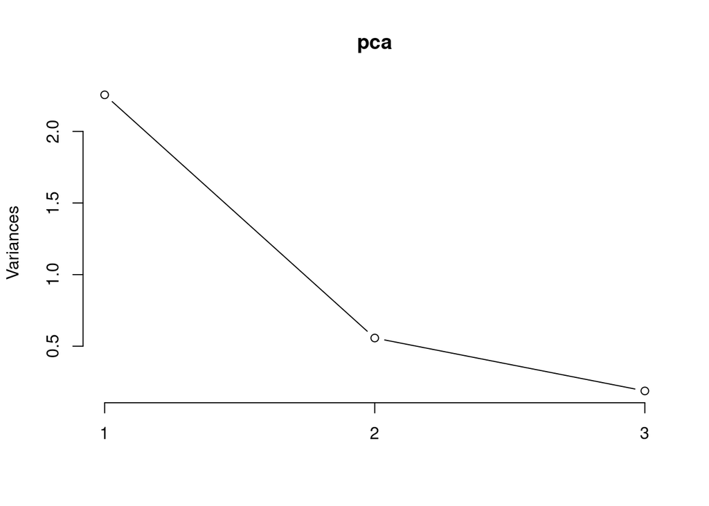

```r
plot(pca,type='l')
```

```r
summary(pca)
```

```
## Importance of components:
##                           PC1    PC2     PC3
## Standard deviation     1.5018 0.7463 0.43297
## Proportion of Variance 0.7518 0.1857 0.06249
## Cumulative Proportion  0.7518 0.9375 1.00000
```

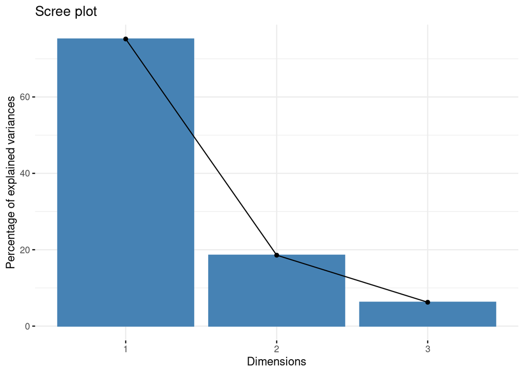

```r
# Plot PCA
library(factoextra)
fviz_eig(pca)
```

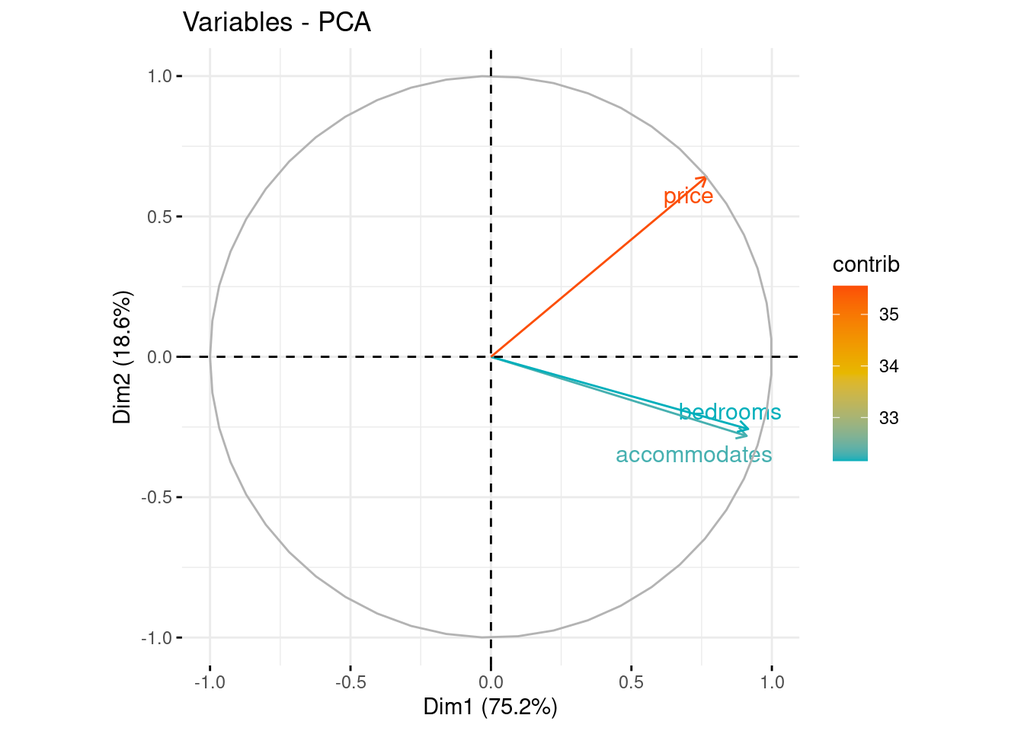

```r
fviz_pca_var(pca,
             col.var = "contrib", # Color by contributions to the PC
             gradient.cols = c("#00AFBB", "#E7B800", "#FC4E07"),
             repel = TRUE     # Avoid text overlapping
)
```

```r
# Predict PCA
pred_pca <- predict(pca, newdata=pca_data)

# Create dataset for PC values and categorical variables
Asheville_new_modified <- cbind.data.frame(Asheville_new_modified,pred_pca[,c(1)])

#Rename principal component
names(Asheville_new_modified)[names(Asheville_new_modified) == 'pred_pca[, c(1)]'] <- 'property_capacity'
```

We check the distribution of numeric variables to see if they satisfy the normality assumption for the linear regression model.

```r
library(plyr)
library(psych)
```

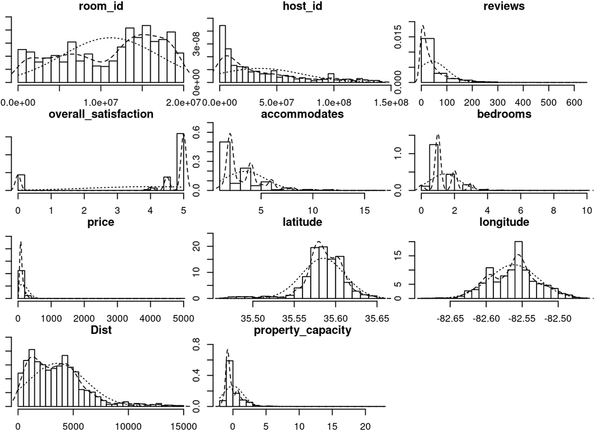

```r
multi.hist(Asheville_new_modified[,sapply(Asheville_new_modified, is.numeric)])
```

Other variables remained with polar distributions (see overall_satisfaction). Consequently, we created a dummy variable that captures if the customer was satisfied with the room or not.

```r
# Transform overall_satisfaction to dummy
Asheville_new_modified$high_satisfaction <- ifelse(Asheville_new_modified$overall_satisfaction < 4,0,1)
```

In addition, we transformed the categorical variables into dummies and renamed them.

```r
#Dummy variable for room_type
library(fastDummies)

Asheville_new_modified <- dummy_cols(Asheville_new_modified, select_columns = 'room_type')

#Dummy variable for neighbourhood
Asheville_new_modified <- dummy_cols(Asheville_new_modified, select_columns = 'neighborhood')

#Rename dummy columns associated with neighborhood

Asheville_new_modified <- rename(Asheville_new_modified, c("neighborhood_Asheville" = "Asheville"))
Asheville_new_modified <- rename(Asheville_new_modified, c("neighborhood_Richmond Hill" = "Richmond_Hill"))
Asheville_new_modified <- rename(Asheville_new_modified, c("neighborhood_Formerly ETJ" = "Formerly_ETJ"))

#Rename dummy columns associated with room type
Asheville_new_modified <- rename(Asheville_new_modified, c("room_type_Entire home/apt" = "Entire_Home_Apt"))
Asheville_new_modified <- rename(Asheville_new_modified, c("room_type_Private room" = "Private_room"))
Asheville_new_modified <- rename(Asheville_new_modified, c("room_type_Shared room" = "Shared_room"))

head(Asheville_new_modified)
```

```
##   room_id host_id       room_type neighborhood reviews overall_satisfaction
## 1   67870  335286    Private room    Asheville     178                  5.0
## 2   80331  433914    Private room    Asheville      57                  5.0
## 3   80905  427027 Entire home/apt    Asheville      67                  5.0
## 4   86981 1675743    Private room    Asheville      44                  5.0
## 5   86983 1675743 Entire home/apt    Asheville      22                  4.5
## 6   86984 1675743    Private room    Asheville      30                  4.5
##   accommodates bedrooms price              last_modified latitude longitude
## 1            2        1    80 2017-07-20 02:53:24.471794 35.55371 -82.62630
## 2            2        1   125 2017-07-20 02:53:42.815688 35.56915 -82.54972
## 3           10        2   190 2017-07-20 02:55:55.976193 35.59701 -82.55237
## 4            2        1    90 2016-09-10 23:26:14.250365 35.58656 -82.54912
## 5           12        4   525 2016-12-26 15:15:01.344537 35.58674 -82.55093
## 6            4        1   100 2016-09-10 23:03:08.403316 35.58664 -82.55039
##        Dist property_capacity high_satisfaction Entire_Home_Apt Private_room
## 1 7970.7541        -0.8324834                 1               0            1
## 2 2850.2941        -0.7013075                 1               0            1
## 3  305.0920         2.5583563                 1               1            0
## 4  995.3072        -0.8033332                 1               0            1
## 5  915.4083         5.5011553                 1               1            0
## 6  941.8142        -0.1778819                 1               0            1
##   Shared_room Asheville Formerly_ETJ Richmond_Hill
## 1           0         1            0             0
## 2           0         1            0             0
## 3           0         1            0             0
## 4           0         1            0             0
## 5           0         1            0             0
## 6           0         1            0             0
```

We removed vars that added noise to the analysis.

```r
#remove unnecessary variable
Asheville_new_modified <- Asheville_new_modified %>% select(-c(room_id))
Asheville_new_modified <- Asheville_new_modified %>% select(-c(host_id))
Asheville_new_modified <- Asheville_new_modified %>% select(-c(room_type))
Asheville_new_modified <- Asheville_new_modified %>% select(-c(neighborhood))
Asheville_new_modified <- Asheville_new_modified %>% select(-c(bedrooms))
Asheville_new_modified <- Asheville_new_modified %>% select(-c(accommodates))
Asheville_new_modified <- Asheville_new_modified %>% select(-c(overall_satisfaction))
Asheville_new_modified <- Asheville_new_modified %>% select(-c(last_modified))
head(Asheville_new_modified)
```

```
##   reviews price latitude longitude      Dist property_capacity
## 1     178    80 35.55371 -82.62630 7970.7541        -0.8324834
## 2      57   125 35.56915 -82.54972 2850.2941        -0.7013075
## 3      67   190 35.59701 -82.55237  305.0920         2.5583563
## 4      44    90 35.58656 -82.54912  995.3072        -0.8033332
## 5      22   525 35.58674 -82.55093  915.4083         5.5011553
## 6      30   100 35.58664 -82.55039  941.8142        -0.1778819
##   high_satisfaction Entire_Home_Apt Private_room Shared_room Asheville
## 1                 1               0            1           0         1
## 2                 1               0            1           0         1
## 3                 1               1            0           0         1
## 4                 1               0            1           0         1
## 5                 1               1            0           0         1
## 6                 1               0            1           0         1
##   Formerly_ETJ Richmond_Hill
## 1            0             0
## 2            0             0
## 3            0             0
## 4            0             0
## 5            0             0
## 6            0             0
```

We identified outliers and removed them too. We all the rooms with prices above 600.

```r
# Remove extreme values

library(dplyr)
Asheville_new_modified <- Asheville_new_modified %>% filter(price < 601)

# Get min and max
max(Asheville_new_modified$price)
```

```
## [1] 600
```

```r
min(Asheville_new_modified$price)
```

```
## [1] 20
```

## Create dataset without text features for all the models

First, We standardized the numeric variables.

```r
# Scale numeric variables
maxs <- apply(Asheville_new_modified,2,max)
mins <- apply(Asheville_new_modified,2,min)

Asheville_scaled <- as.data.frame(scale(Asheville_new_modified, center = mins, scale=maxs-mins)) # (x-a)/(b-a)
```

Second, we split the data into training and test set.

```r
#Create id
library(caret)
set.seed(110)

Asheville_scaled$id <- seq.int(nrow(Asheville_scaled))

#Split data
Asheville.train <- Asheville_scaled %>% sample_frac(0.70)
Asheville.test <- anti_join(Asheville_scaled, Asheville.train, by="id")

#Remove the id from training and test set
Asheville.train$id <- NULL
Asheville.test$id <- NULL
```

### Text mining

In addition to the continuous features, we also extracted text and performed feature engineering. We start by creating a corpus.

```r
# Establish the corpus and initial DFM matrix
library(quanteda)
myCorpus <- corpus(Airbnb_asheville_merged$name)
summary(myCorpus)
```

```
## Corpus consisting of 5639 documents, showing 100 documents:
##
##     Text Types Tokens Sentences
##    text1     0      0         0
##    text2     0      0         0
##    text3     0      0         0
##    text4     9      9         3
##    text5     9      9         3
##    text6     9      9         3
##    text7     9      9         3
##    text8     0      0         0
##    text9     0      0         0
##   text10     0      0         0
##   text11     6      8         1
##   text12     6      8         1
##   text13     6      8         1
##   text14     6      8         1
##   text15     0      0         0
##   text16     0      0         0
##   text17     0      0         0
##   text18     4      4         1
##   text19     4      4         1
##   text20     4      4         1
##   text21     4      4         1
##   text22     0      0         0
##   text23     0      0         0
##   text24     0      0         0
##   text25     0      0         0
##   text26     0      0         0
##   text27     0      0         0
##   text28     0      0         0
##   text29     5      5         1
##   text30     5      5         1
##   text31     0      0         0
##   text32     0      0         0
##   text33     0      0         0
##   text34     0      0         0
##   text35     0      0         0
##   text36     6      6         2
##   text37     6      6         2
```

[output cut: 48 more lines]

```
##   text86     0      0         0
##   text87     0      0         0
##   text88     5      5         1
##   text89     5      5         1
##   text90     5      5         1
##   text91     5      5         1
##   text92     0      0         0
##   text93     0      0         0
##   text94     0      0         0
##   text95     7      7         1
##   text96     7      7         1
##   text97     7      7         1
##   text98    10     10         2
##   text99     0      0         0
##  text100     0      0         0
```

```r
myDfm <- dfm(myCorpus)
dim(myDfm)
```

```
## [1] 5639 1170
```

Then, we get the most frequent terms.

```r
# Simple frequency analyses
library(quanteda.textstats)
tstat_freq <- textstat_frequency(myDfm)
head(tstat_freq, 20)
```

```
##      feature frequency rank docfreq group
## 1  asheville      1013    1    1009   all
## 2   downtown       829    2     823   all
## 3          ,       647    3     464   all
## 4         in       590    4     585   all
## 5          !       513    5     452   all
## 6       west       483    6     479   all
## 7         to       462    7     458   all
## 8        the       406    8     394   all
## 9    private       400    9     385   all
## 10      home       325   10     310   all
## 11         /       304   11     270   all
## 12         .       302   12     255   all
## 13      room       258   13     258   all
## 14       and       226   14     222   all
## 15         -       224   15     222   all
## 16      cozy       220   16     220   all
## 17         &       218   17     212   all
## 18     suite       216   18     216   all
## 19 apartment       208   19     208   all
## 20   cottage       183   20     175   all
```

```r
docvars(myCorpus, "room_id") <- Airbnb_asheville_merged$room_id
summary(myCorpus)
```

```
## Corpus consisting of 5639 documents, showing 100 documents:
##
##     Text Types Tokens Sentences room_id
##    text1     0      0         0   67870
##    text2     0      0         0   67870
##    text3     0      0         0   67870
##    text4     9      9         3   67870
##    text5     9      9         3   67870
##    text6     9      9         3   67870
##    text7     9      9         3   67870
##    text8     0      0         0   80331
##    text9     0      0         0   80331
##   text10     0      0         0   80331
##   text11     6      8         1   80331
##   text12     6      8         1   80331
##   text13     6      8         1   80331
##   text14     6      8         1   80331
##   text15     0      0         0   80905
##   text16     0      0         0   80905
##   text17     0      0         0   80905
##   text18     4      4         1   80905
##   text19     4      4         1   80905
##   text20     4      4         1   80905
##   text21     4      4         1   80905
##   text22     0      0         0   86981
##   text23     0      0         0   86983
##   text24     0      0         0   86983
##   text25     0      0         0   86984
##   text26     0      0         0  136547
##   text27     0      0         0  136547
##   text28     0      0         0  136547
##   text29     5      5         1  136547
##   text30     5      5         1  136547
##   text31     0      0         0  151444
##   text32     0      0         0  151444
##   text33     0      0         0  155305
##   text34     0      0         0  155305
##   text35     0      0         0  155305
##   text36     6      6         2  155305
##   text37     6      6         2  155305
```

[output cut: 48 more lines]

```
##   text86     0      0         0  266511
##   text87     0      0         0  266511
##   text88     5      5         1  266511
##   text89     5      5         1  266511
##   text90     5      5         1  266511
##   text91     5      5         1  266511
##   text92     0      0         0  273534
##   text93     0      0         0  273534
##   text94     0      0         0  273534
##   text95     7      7         1  273534
##   text96     7      7         1  273534
##   text97     7      7         1  273534
##   text98    10     10         2  273534
##   text99     0      0         0  284690
##  text100     0      0         0  284690
```

We removed stopwords and less frequent terms.

```r
# Remove stop words & perform stemming
myDfm <- dfm(myCorpus,
               remove_numbers = T,
               remove_punc = T,
               remove = c(stopwords("english"), "~", "w", "b"),
               stem = T)
topfeatures(myDfm,50)
```

```
## ashevill downtown     west   privat     home     room     cozi     suit
##     1022      829      483      400      325      264      220      217
##    apart     walk   cottag bungalow    close  biltmor     near     hous
##      208      201      183      173      164      147      144      143
##    locat      apt   histor mountain   studio     loft   modern      avl
##      133      129      124      118      117      115      112      107
##  bedroom  retreat   beauti montford    quiet     bath spacious      art
##      107      106      105      102      101       97       96       93
##    heart   luxuri    charm     town     view  conveni      new    great
##       92       90       85       82       74       73       72       72
##     citi      bed    river      min  everyth    sunni     love   friend
##       69       67       66       66       64       61       61       56
##     peac     mile
##       56       56
```

```r
myDfm<- dfm_trim(myDfm,min_termfreq=4, min_docfreq=2)
```

We created a word cloud of our tokens.

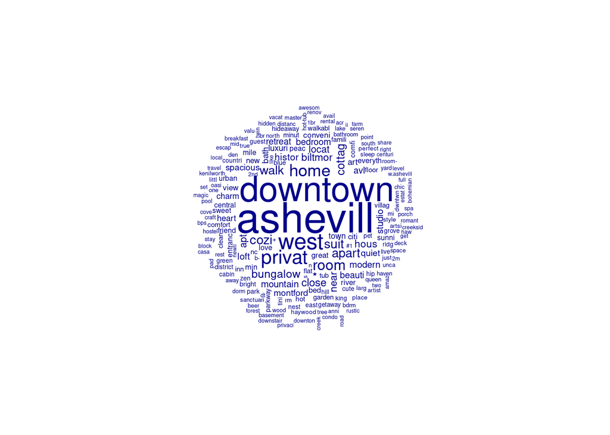

```r
library(quanteda.textplots)
# Wordcloud
textplot_wordcloud(myDfm,max_words=200)
```

```r
dim(myDfm)
```

```
## [1] 5639  681
```

We create a tfidf dataframe and run lsa to get the new text features.

```r
library (quanteda.textmodels)
# Perform SVD for dimension reduction
modelDfm_tfidf <- dfm_tfidf(myDfm)
dim(modelDfm_tfidf)
```

```
## [1] 5639  681
```

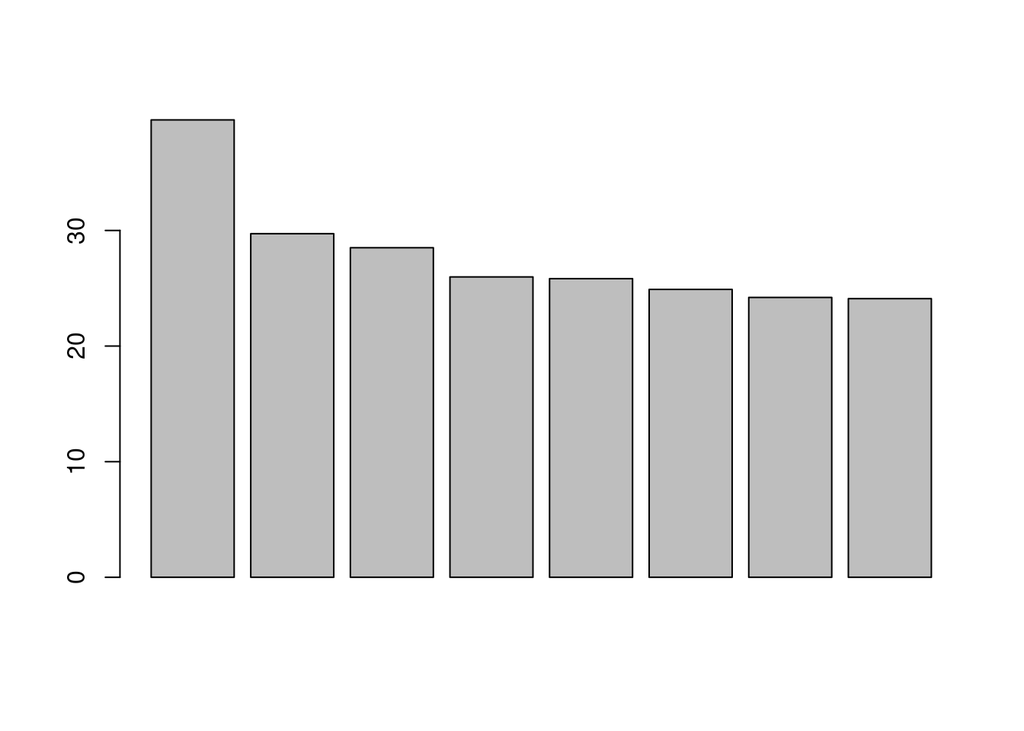

```r
modelSvd <- textmodel_lsa(modelDfm_tfidf, nd = 8)
barplot(modelSvd$sk)
```

```r
ReducedData <- modelSvd$docs %*% diag(modelSvd$sk)
```

We merge the new data to the original dataset.

```r
# Add the non-text information
modelData <- cbind(Airbnb_asheville_merged, as.data.frame(ReducedData))
str(modelData)
```

```
## 'data.frame':    5639 obs. of  28 variables:
##  $ room_id             : num  67870 67870 67870 67870 67870 ...
##  $ host_id             : num  335286 335286 335286 335286 335286 ...
##  $ room_type           : chr  "Private room" "Private room" "Private room" "Private room" ...
##  $ borough             : logi  NA NA NA NA NA NA ...
##  $ neighborhood        : chr  "Asheville" "Asheville" "Asheville" "Asheville" ...
##  $ reviews             : num  164 170 172 176 176 177 178 50 53 53 ...
##  $ overall_satisfaction: num  5 5 5 5 5 5 5 5 5 5 ...
##  $ accommodates        : num  2 2 2 2 2 2 2 2 2 2 ...
##  $ bedrooms            : num  1 1 1 1 1 1 1 1 1 1 ...
##  $ price               : num  66 82 82 75 90 80 80 135 120 120 ...
##  $ minstay             : num  1 NA NA NA NA NA NA 2 NA NA ...
##  $ last_modified       : chr  "2016-09-10 23:25:49.263062" "2016-12-26 15:13:03.614349" "2017-03-10 19:16:20.100999" "2017-04-12 12:09:47.964790" ...
##  $ latitude            : num  35.6 35.6 35.6 35.6 35.6 ...
##  $ longitude           : num  -82.6 -82.6 -82.6 -82.6 -82.6 ...
##  $ survey_id           : num  NA NA NA 1097 1256 ...
##  $ country             : logi  NA NA NA NA NA NA ...
##  $ city                : chr  NA NA NA "Asheville" ...
##  $ bathrooms           : logi  NA NA NA NA NA NA ...
##  $ name                : chr  NA NA NA "Your Own Floor! 1 bdrm W. Asheville" ...
##  $ location            : chr  NA NA NA "0101000020E61000004E25034015A854C07C48F8DEDFC64140" ...
##  $ V1                  : num  0 0 0 0.429 0.429 ...
##  $ V2                  : num  0 0 0 -0.409 -0.409 ...
##  $ V3                  : num  0 0 0 -0.171 -0.171 ...
##  $ V4                  : num  0 0 0 0.198 0.198 ...
##  $ V5                  : num  0 0 0 -0.165 -0.165 ...
##  $ V6                  : num  0 0 0 0.904 0.904 ...
##  $ V7                  : num  0 0 0 0.392 0.392 ...
##  $ V8                  : num  0 0 0 -0.201 -0.201 ...
```

We remove duplicate listings.

```r
#dataset with each unique listing
asheville_textfeatures <- modelData %>%
  arrange(room_id, desc(last_modified)) %>%
  distinct(room_id, .keep_all = TRUE)
```

We create merge the text features to the cleaned dataset.

```r
  library(dplyr)
  #create id
  asheville_textfeatures$id <- seq.int(nrow(asheville_textfeatures))
  head(asheville_textfeatures)
```

```
##   room_id host_id       room_type borough neighborhood reviews
## 1   67870  335286    Private room      NA    Asheville     178
## 2   80331  433914    Private room      NA    Asheville      57
## 3   80905  427027 Entire home/apt      NA    Asheville      67
## 4   86981 1675743    Private room      NA    Asheville      44
## 5   86983 1675743 Entire home/apt      NA    Asheville      22
## 6   86984 1675743    Private room      NA    Asheville      30
##   overall_satisfaction accommodates bedrooms price minstay
## 1                  5.0            2        1    80      NA
## 2                  5.0            2        1   125      NA
## 3                  5.0           10        2   190      NA
## 4                  5.0            2        1    90       2
## 5                  4.5           12        4   525      NA
## 6                  4.5            4        1   100       2
##                last_modified latitude longitude survey_id country      city
```

[output cut: 27 more lines]

```r
  # extract text features
  textfeatures <- asheville_textfeatures %>% select(id,V1,V2,V3,V4,V5,V6,V7,V8)
  head(textfeatures)
```

```
##   id        V1         V2           V3        V4         V5          V6
## 1  1 0.4289572 -0.4092924 -0.170608217 0.1983726 -0.1647433  0.90372292
## 2  2 0.5942837 -0.5644324 -0.009589331 0.6258838 -0.5841112 -0.45749533
## 3  3 0.1962686 -0.1210919  0.234412278 0.2068891  0.5209103  0.06796343
## 4  4 0.0000000  0.0000000  0.000000000 0.0000000  0.0000000  0.00000000
## 5  5 0.0000000  0.0000000  0.000000000 0.0000000  0.0000000  0.00000000
## 6  6 0.0000000  0.0000000  0.000000000 0.0000000  0.0000000  0.00000000
##          V7         V8
## 1 0.3920989 -0.2014142
## 2 0.2662619  0.1010157
## 3 0.1062775  0.5121968
## 4 0.0000000  0.0000000
## 5 0.0000000  0.0000000
## 6 0.0000000  0.0000000
```

```r
  #Create id
  Asheville_new_modified$id <- seq.int(nrow(Asheville_new_modified))

  #merge the datasets
  data_plustext <- merge(Asheville_scaled,textfeatures,by="id")
  head(data_plustext)
```

```
##   id    reviews     price  latitude longitude       Dist property_capacity
## 1  1 0.29568106 0.1034483 0.4613651 0.2576959 0.54463790         0.1260901
## 2  2 0.09468439 0.1810345 0.5444335 0.6020007 0.19296587         0.1417098
## 3  3 0.11129568 0.2931034 0.6942719 0.5900641 0.01816197         0.5298504
## 4  4 0.07308970 0.1206897 0.6381040 0.6046802 0.06556579         0.1295612
## 5  5 0.03654485 0.8706897 0.6390453 0.5965247 0.06007836         0.8802607
## 6  6 0.04983389 0.1379310 0.6385182 0.5989794 0.06189191         0.2040360
##   high_satisfaction Entire_Home_Apt Private_room Shared_room Asheville
## 1                 1               0            1           0         1
## 2                 1               0            1           0         1
## 3                 1               1            0           0         1
## 4                 1               0            1           0         1
## 5                 1               1            0           0         1
## 6                 1               0            1           0         1
##   Formerly_ETJ Richmond_Hill        V1         V2           V3        V4
## 1            0             0 0.4289572 -0.4092924 -0.170608217 0.1983726
## 2            0             0 0.5942837 -0.5644324 -0.009589331 0.6258838
## 3            0             0 0.1962686 -0.1210919  0.234412278 0.2068891
## 4            0             0 0.0000000  0.0000000  0.000000000 0.0000000
## 5            0             0 0.0000000  0.0000000  0.000000000 0.0000000
## 6            0             0 0.0000000  0.0000000  0.000000000 0.0000000
##           V5          V6        V7         V8
## 1 -0.1647433  0.90372292 0.3920989 -0.2014142
## 2 -0.5841112 -0.45749533 0.2662619  0.1010157
## 3  0.5209103  0.06796343 0.1062775  0.5121968
## 4  0.0000000  0.00000000 0.0000000  0.0000000
## 5  0.0000000  0.00000000 0.0000000  0.0000000
## 6  0.0000000  0.00000000 0.0000000  0.0000000
```

Apply the same process to the data with text features.

```r
#Create id
library(caret)
set.seed(110)

#Split data
Asheville_plustext.train <- data_plustext %>% sample_frac(0.70)
Asheville_plustext.test <- anti_join(data_plustext, Asheville_plustext.train, by="id")

#Remove the id from training and test set
Asheville_plustext.train$id <- NULL
Asheville_plustext.test$id <- NULL
```

## Neural Network

```r
# Train the neural net model
library(neuralnet)
```

```r
nn <- neuralnet(price ~ reviews + high_satisfaction + latitude + longitude + property_capacity + Dist + Richmond_Hill + Formerly_ETJ + Private_room + Entire_Home_Apt, data=Asheville.train, hidden = c(2),
                algorithm = "rprop+",
                linear.output=TRUE)

#Plot a neural network
plot(nn)
```

[output not shown]

## Model Evaluation

```r
# Predict
test_no_target <- subset(Asheville.test, select=-c(price))
pr.nn <- neuralnet::compute(nn, test_no_target)

# Results from NN are normalized (scaled). We need to rescale for comparison.
pr.nn_ <- pr.nn$net.result*(max(Asheville_new_modified$price)-min(Asheville_new_modified$price))+min(Asheville_new_modified$price)

# Calculating MSE
MSE.nn <- sum((Asheville.test$price - pr.nn$net.result)^2)/nrow(Asheville.test)
RMSE.nn <-  sqrt(MSE.nn)
RMSE.nn
```

```
## [1] 0.08087062
```

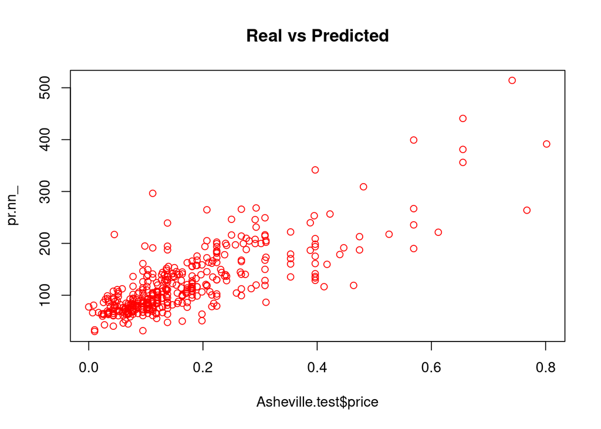

```r
plot(Asheville.test$price, pr.nn_, col = "red",
     main = 'Real vs Predicted')
abline(0, 1, lwd = 2)
```

Compute the R squared for the neural network (Test dataset)

```r
ydi<- Asheville.test$price
yi<- predict(nn,test_no_target)
ym<-mean(Asheville.test$price)
R<-1- ((sum((yi-ydi)^2))/(sum((ydi-ym)^2)))
R
```

```
## [1] 0.6140964
```

## Neural Network with text features

```r
# Train the neural net model
library(neuralnet)

nn_text <- neuralnet(price ~ reviews + high_satisfaction + latitude + longitude + property_capacity + Dist + Richmond_Hill + Formerly_ETJ + Private_room + Entire_Home_Apt + V1 + V2 + V3 + V4 + V5 + V6 + V7 + V8, data=Asheville_plustext.train, hidden = c(2),
                algorithm = "rprop+",
                linear.output=TRUE)

#Plot a neural network
plot(nn_text)
```

[output not shown]

## Model Evaluation

```r
# Predict
test_no_target2 <- subset(Asheville_plustext.test, select=-c(price))
pr.nn2 <- neuralnet::compute(nn_text, test_no_target2)

# Results from NN are normalized (scaled). We need to rescale for comparison.
pr.nn2_ <- pr.nn2$net.result*(max(data_plustext$price)-min(data_plustext$price))+min(data_plustext$price)

# Calculating MSE
MSE2.nn <- sum((Asheville_plustext.test$price - pr.nn2$net.result)^2)/nrow(Asheville_plustext.test)
RMSE2.nn <-  sqrt(MSE2.nn)
RMSE2.nn
```

```
## [1] 0.08241416
```

Compute the R squared for the neural network with text features (Test dataset)

```r
ydi<- Asheville_plustext.test$price
yi<- predict(nn_text,test_no_target2)
ym<-mean(Asheville_plustext.test$price)
R<-1- ((sum((yi-ydi)^2))/(sum((ydi-ym)^2)))
R
```

```
## [1] 0.5992247
```

The neural network performs worst with text features, probably due to overfilling.

## Random forest

```r
require(randomForest)
Asheville.rf = randomForest(price~., data = Asheville.train)
Asheville.rf
```

```
##
## Call:
##  randomForest(formula = price ~ ., data = Asheville.train)
##                Type of random forest: regression
##                      Number of trees: 500
## No. of variables tried at each split: 4
##
##           Mean of squared residuals: 0.005711536
##                     % Var explained: 65.24
```

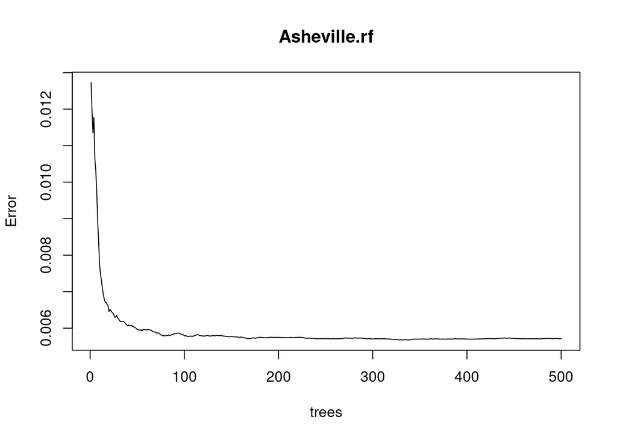

```r
plot(Asheville.rf)
```

```r
# Create var to store out of bag error and test error
oob.err=double(12)
test.err=double(12)

#Find optimal mtry
for(mtry in 1:12)
{
  Asheville.rf=randomForest(price~., data = Asheville.train, mtry=mtry,ntree=400)
  oob.err[mtry] = Asheville.rf$mse[400] #Error of all Trees fitted

  pred<-predict(Asheville.rf,Asheville.train) #Predictions on Test Set for each Tree
  test.err[mtry]= with(Asheville.train, mean(price - as.numeric(pred))^2) #Mean Squared Test Error
  cat(mtry," ") #printing the output to the console

}
```

```
## 1  2  3  4  5  6  7  8  9  10  11  12
```

```r
#Print test error and out of bag error
test.err
```

```
##  [1] 1.649236e-08 4.424707e-08 3.462759e-11 6.786046e-08 6.333937e-08
##  [6] 3.949770e-08 7.792140e-09 3.997536e-07 1.774975e-07 2.355076e-08
## [11] 2.446624e-07 3.661157e-07
```

```r
oob.err
```

```
##  [1] 0.010444223 0.007145102 0.005988550 0.005762649 0.005604537 0.005473778
##  [7] 0.005483552 0.005454834 0.005341006 0.005429228 0.005503691 0.005509501
```

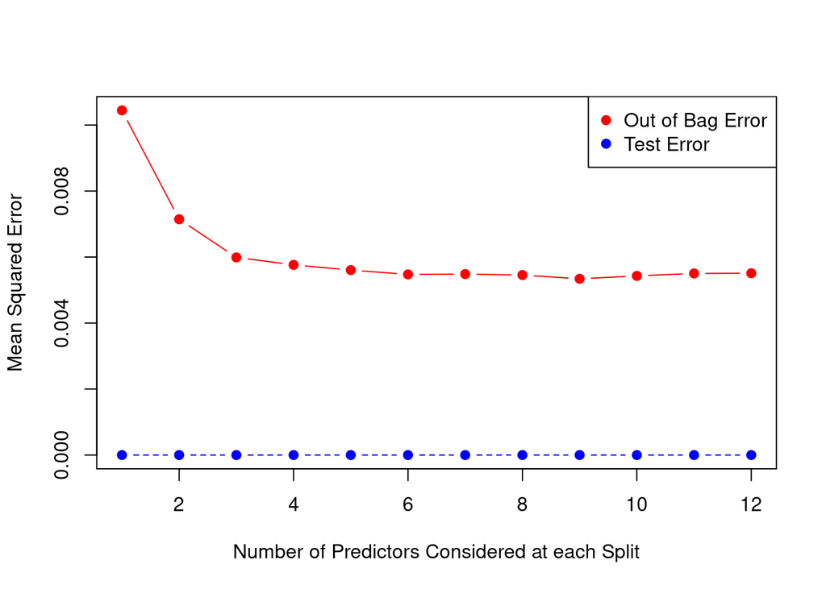

```r
#Plot error
matplot(1:mtry, cbind(oob.err,test.err), pch=19 , col=c("red","blue"),type="b",ylab="Mean Squared Error",xlab="Number of Predictors Considered at each Split")
legend("topright",legend=c("Out of Bag Error","Test Error"),pch=19, col=c("red","blue"))
```

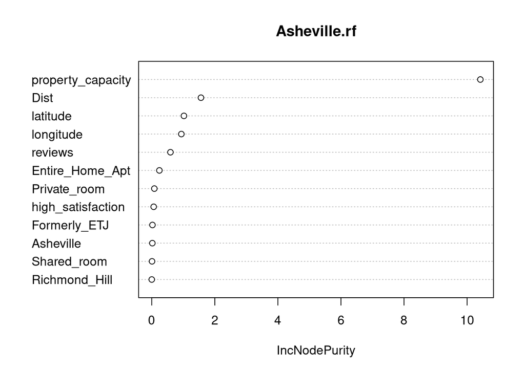

```r
#Plot the feature importance
varImpPlot(Asheville.rf)
```

```r
# number of trees with lowest MSE
which.min(Asheville.rf$mse)
```

```
## [1] 400
```

```r
## [1] 187

# RMSE of this optimal random forest
sqrt(Asheville.rf$mse[which.min(Asheville.rf$mse)])
```

```
## [1] 0.07422601
```

```r
# Get R squared of this optimal random forest
ydi<- Asheville.test$price
yi<- predict(Asheville.rf,test_no_target)
ym<-mean(Asheville.test$price)
R<-1- ((sum((yi-ydi)^2))/(sum((ydi-ym)^2)))
R
```

```
## [1] 0.7043414
```

Results that a tuned random forest model performs best at predicting price in the test dataset.

## Random forest with text features

```r
require(randomForest)

Asheville.rf_text = randomForest(price~., data = Asheville_plustext.train)
Asheville.rf_text
```

```
##
## Call:
##  randomForest(formula = price ~ ., data = Asheville_plustext.train)
##                Type of random forest: regression
##                      Number of trees: 500
## No. of variables tried at each split: 6
##
##           Mean of squared residuals: 0.006114942
##                     % Var explained: 62.79
```

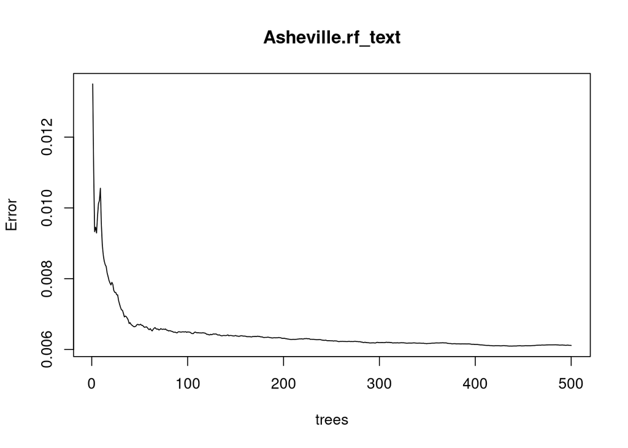

```r
plot(Asheville.rf_text)
```

```r
# Create var to store out of bag error and test error
oob.err2=double(12)
test.err2=double(12)

#Find optimal mtry
for(mtry in 1:12)
{
  Asheville.rf_text=randomForest(price~., data = Asheville_plustext.train, mtry=mtry,ntree=400)
  oob.err2[mtry] = Asheville.rf_text$mse[400] #Error of all Trees fitted

  pred2<-predict(Asheville.rf_text,Asheville_plustext.train) #Predictions on Test Set for each Tree
  test.err2[mtry]= with(Asheville_plustext.train, mean(price - as.numeric(pred))^2) #Mean Squared Test Error
  cat(mtry," ") #printing the output to the console

}
```

```
## 1  2  3  4  5  6  7  8  9  10  11  12
```

```r
#Print test error and out of bag error
test.err2
```

```
##  [1] 3.661157e-07 3.661157e-07 3.661157e-07 3.661157e-07 3.661157e-07
##  [6] 3.661157e-07 3.661157e-07 3.661157e-07 3.661157e-07 3.661157e-07
## [11] 3.661157e-07 3.661157e-07
```

```r
oob.err2
```

```
##  [1] 0.010890535 0.007774380 0.006748609 0.006323598 0.006219687 0.005979500
##  [7] 0.005868105 0.005986950 0.005840326 0.005848608 0.005790712 0.005759270
```

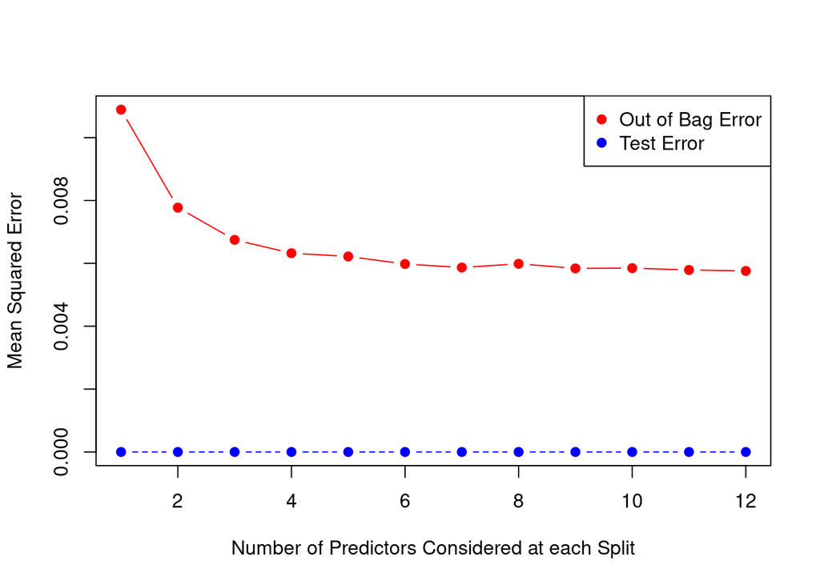

```r
#Plot error
matplot(1:mtry, cbind(oob.err2,test.err2), pch=19 , col=c("red","blue"),type="b",ylab="Mean Squared Error",xlab="Number of Predictors Considered at each Split")
legend("topright",legend=c("Out of Bag Error","Test Error"),pch=19, col=c("red","blue"))
```

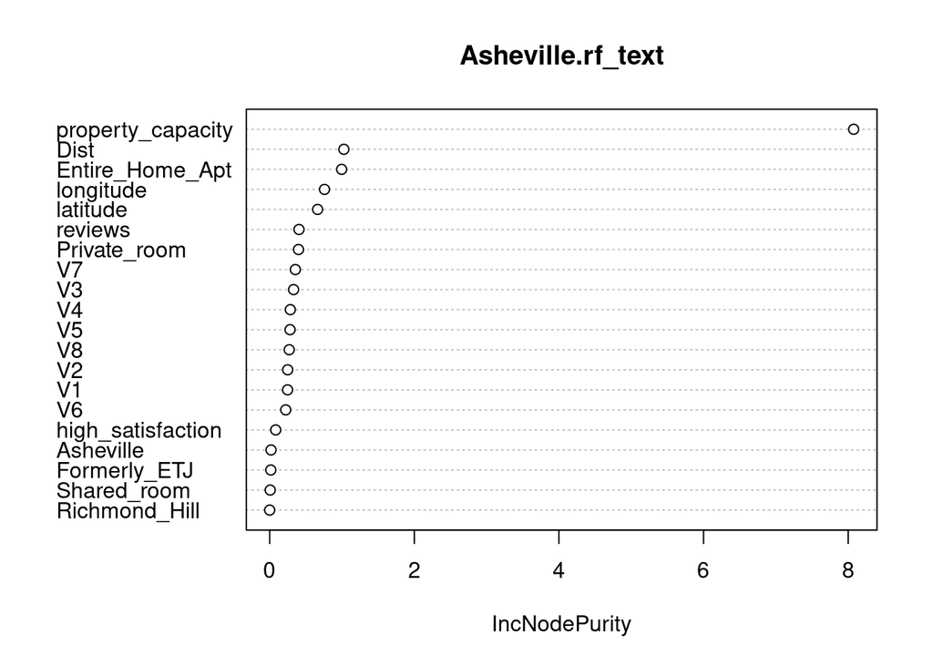

```r
#Plot the feature importance
varImpPlot(Asheville.rf_text)
```

```r
# number of trees with lowest MSE
which.min(Asheville.rf_text$mse)
```

```
## [1] 347
```

```r
## [1] 187

# RMSE of this optimal random forest
sqrt(Asheville.rf_text$mse[which.min(Asheville.rf_text$mse)])
```

```
## [1] 0.07579417
```

```r
# Get R squared of this optimal random forest
ydi<- Asheville_plustext.test$price
yi<- predict(Asheville.rf_text,test_no_target2)
ym<-mean(Asheville_plustext.test$price)
R<-1- ((sum((yi-ydi)^2))/(sum((ydi-ym)^2)))
R
```

```
## [1] 0.6905551
```

## KNN model

```r
# Subset the database
library(dplyr)
dtrain.x <- Asheville.train %>% select(-price) # remove price
dtrain.y <- Asheville.train %>% select(price) # keep only price

dtest.x <- Asheville.test %>% select(-price) # remove price
dtest.y <- Asheville.test %>% select(price) # keep only price
```

To get the optimal number of k, we compared several knn models and choose the model with the lowest MSE.

```r
# run several knn with different K values
model <- kknn::train.kknn(price~., data = Asheville.train, kmax = 30)
model
```

```
##
## Call:
## kknn::train.kknn(formula = price ~ ., data = Asheville.train,     kmax = 30)
##
## Type of response variable: continuous
## minimal mean absolute error: 0.05402504
## Minimal mean squared error: 0.006980958
## Best kernel: optimal
## Best k: 12
```

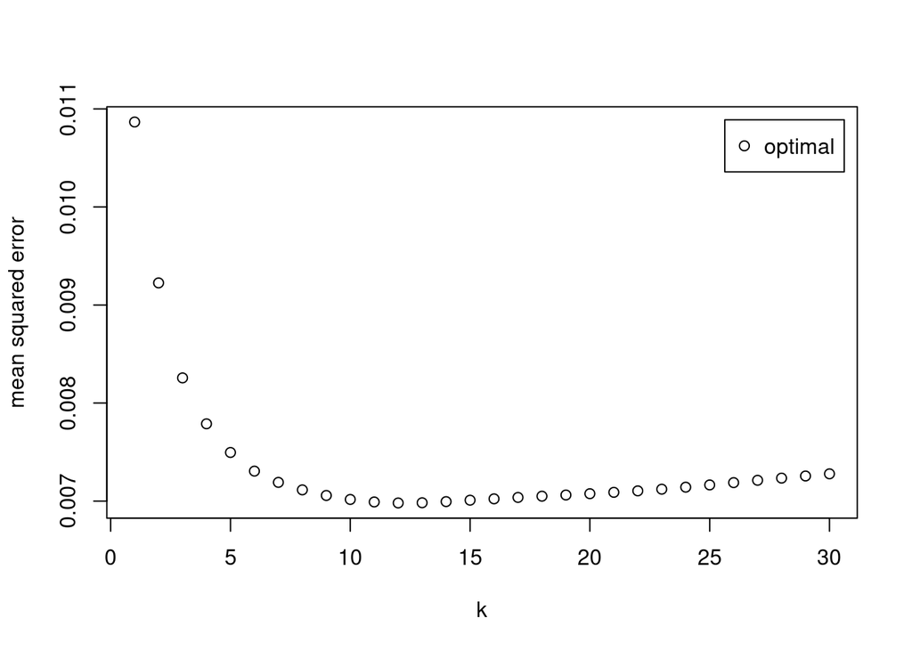

```r
#Visualize knn regression and MSE error
plot(model)
```

The k value that minimizes the MSE is 12.

## Prepare the data for Knn.

Train KNN with the optimal number of k.

```r
# Train a knn regression
library(FNN)
pred.a <- FNN::knn.reg(dtrain.x, dtest.x, dtrain.y, k = 12)
```

Then, we get the predictions for our test data.

```r
#Make a copy of our dataset containing the true values of the dependent variable for the testing data. This dataset was called dtest.y and the new copy of it will be called dtest.y.results:
dtest.y.results <- dtest.y

#Next, we will add the predictions made in pred.a to the new dtest.y.results dataset:
dtest.y.results$k12.pred <- pred.a$pred

#Look at the predictions
head(dtest.y.results,n=nrow(dtest.y.results))
```

```
##           price   k12.pred
## 1   0.293103448 0.38031609
## 2   0.224137931 0.18778736
## 3   0.068965517 0.10229885
## 4   0.082758621 0.15977011
## 5   0.137931034 0.15359195
## 6   0.029310345 0.16824713
## 7   0.396551724 0.31637931
## 8   0.170689655 0.14683908
## 9   0.206896552 0.20617816
## 10  0.206896552 0.17931034
## 11  0.022413793 0.09195402
## 12  0.215517241 0.13304598
## 13  0.137931034 0.10359195
## 14  0.063793103 0.08390805
```

[output cut: 378 more lines]

Let’s calculate the RMSE for the predictive model we just made. To do this, we use the rmse function from the Metrics package and we feed the actual and predicted values into the function:

```r
library(Metrics)
rmse(dtest.y.results$price,dtest.y.results$k12.pred)
```

```
## [1] 0.08451375
```

Get the R squared

```r
# Get R squared
ydi<- Asheville.test$price
yi<- dtest.y.results$k12.pred
ym<-mean(Asheville.test$price)
R<-1- ((sum((yi-ydi)^2))/(sum((ydi-ym)^2)))
R
```

```
## [1] 0.5785441
```

The KNN has a reasonable performance. It achieves a R-squared of 0.57.

## KNN with text features.

```r
# Subset the database
library(dplyr)
dtrain_plustext.x <- Asheville_plustext.train %>% select(-price) # remove price
dtrain_plustext.y <- Asheville_plustext.train %>% select(price) # keep only price

dtest_plustext.x <- Asheville_plustext.test %>% select(-price) # remove price
dtest_plustext.y <- Asheville_plustext.test %>% select(price) # keep only price
```

Now we train the KNN model with the text features

```r
# Train a knn regression

library(FNN)
pred.a.text <- FNN::knn.reg(dtrain_plustext.x, dtest_plustext.x, dtrain.y, k = 12)
```

```r
#Make a copy of our dataset containing the true values of the dependent variable for the testing data. This dataset was called dtest.y and the new copy of it will be called dtest.y.results:
dtestplustext.y.results <- dtest_plustext.y

#Next, we will add the predictions made in pred.a to the new dtest.y.results dataset:
dtestplustext.y.results$k12_text.pred <- pred.a.text$pred

#Look at the predictions
head(dtestplustext.y.results,n=nrow(dtestplustext.y.results))
```

```
##           price k12_text.pred
## 1   0.293103448    0.29066092
## 2   0.224137931    0.19583333
## 3   0.068965517    0.07040230
## 4   0.082758621    0.23778736
## 5   0.137931034    0.22500000
## 6   0.029310345    0.17787356
## 7   0.396551724    0.26120690
## 8   0.170689655    0.16163793
## 9   0.206896552    0.19080460
## 10  0.206896552    0.16465517
## 11  0.022413793    0.08620690
## 12  0.215517241    0.13692529
## 13  0.137931034    0.06637931
## 14  0.063793103    0.06178161
```

[output cut: 378 more lines]

Let’s calculate the RMSE for the predictive model we just made. To do this, we use the rmse function from the Metrics package and we feed the actual and predicted values into the function:

```r
library(Metrics)
rmse(dtestplustext.y.results$price,dtestplustext.y.results$k12_text)
```

```
## [1] 0.1013182
```

Get the R squared

```r
# Get R squared
ydi<- Asheville_plustext.test$price
yi<- dtestplustext.y.results$k12_text
ym<-mean(Asheville_plustext.test$price)
R<-1- ((sum((yi-ydi)^2))/(sum((ydi-ym)^2)))
R
```

```
## [1] 0.3942798
```

KNN performs worst with the text features. This occurs because the cluster are of lower quality.

## Decision Tree

```r
# Train a decision tree
library(rpart)
library(rattle)
```

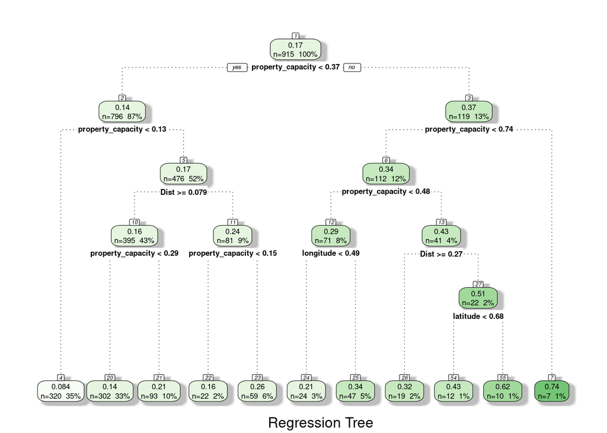

```r
tree1 <- rpart(price ~ ., data=Asheville.train, method = 'anova')

# Plot the decision tree

fancyRpartPlot(tree1, caption = "Regression Tree")
```

```r
# Get the variable importance
library(caret)
(varimp.tree1 <- varImp(tree1))
```

```
##                      Overall
## Asheville         0.04820814
## Dist              1.12883847
## Entire_Home_Apt   0.51811453
## Formerly_ETJ      0.04559559
## high_satisfaction 0.15840731
## latitude          1.03037005
## longitude         1.07066586
## Private_room      0.43832534
## property_capacity 1.59818256
## reviews           0.27538562
## Shared_room       0.00000000
## Richmond_Hill     0.00000000
```

Predict on new data.

```r
dtest.y$tree1.pred <- predict(tree1, newdata = dtest.x)
head(dtest.y)
```

```
##        price tree1.pred
## 1 0.29310345 0.61810345
## 2 0.22413793 0.14381137
## 3 0.06896552 0.08370151
## 4 0.08275862 0.08370151
## 5 0.13793103 0.14381137
## 6 0.02931034 0.08370151
```

Let’s calculate the RMSE for the predictive model we just made. To do this, we use the rmse function from the Metrics package and we feed the actual and predicted values into the function:

```r
library(Metrics)
rmse(dtest.y$price,dtest.y$tree1.pred)
```

```
## [1] 0.09036185
```

Compute the R squared.

```r
# Get R squared
ydi<- Asheville.test$price
yi<- predict(tree1, newdata = dtest.x)
ym<-mean(Asheville.test$price)
R<-1- ((sum((yi-ydi)^2))/(sum((ydi-ym)^2)))
R
```

```
## [1] 0.5181991
```

## Decision Tree with text features

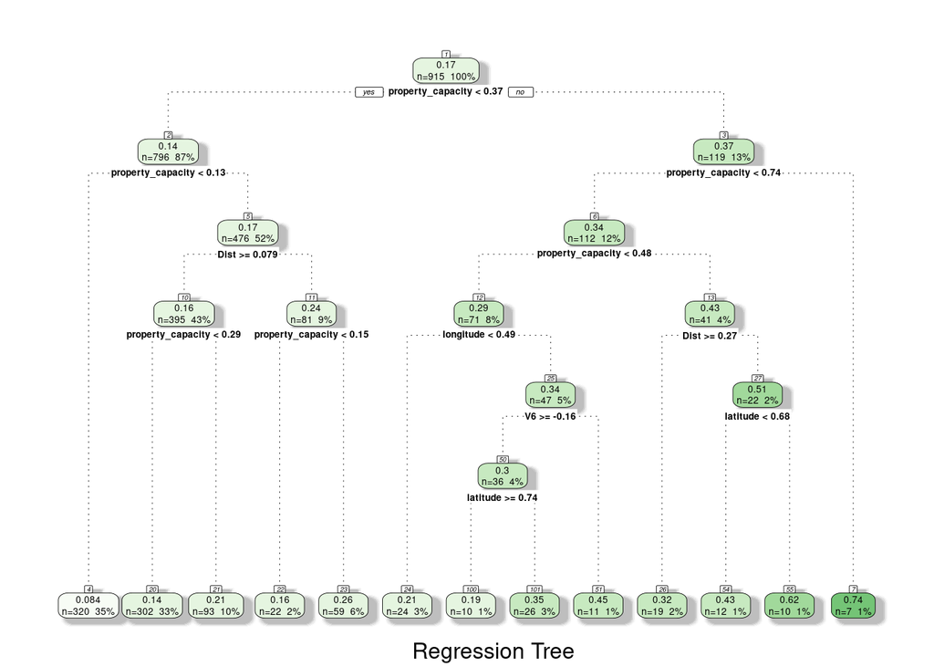

```r
# Train a decision tree
library(rpart)
library(rattle)
tree1_text <- rpart(price ~ ., data=Asheville_plustext.train, method = 'anova')

# Plot the decision tree

fancyRpartPlot(tree1_text, caption = "Regression Tree")
```

```r
# Get the variable importance
library(caret)
(varimp.tree1_text <- varImp(tree1_text))
```

```
##                     Overall
## Dist              1.1288385
## Entire_Home_Apt   0.5181145
## high_satisfaction 0.1032130
## latitude          1.4296313
## longitude         1.0706659
## Private_room      0.4383253
## property_capacity 1.6039101
## reviews           0.1579539
## V1                0.2315728
## V2                0.3846691
## V3                0.1331842
## V4                0.1170229
## V5                0.6618513
## V6                0.3527991
## V7                0.2012311
## Shared_room       0.0000000
## Asheville         0.0000000
## Formerly_ETJ      0.0000000
## Richmond_Hill     0.0000000
## V8                0.0000000
```

Predict on new data.

```r
dtest.y$tree1_text.pred <- predict(tree1_text, newdata = dtest_plustext.x)
head(dtest.y)
```

```
##        price tree1.pred tree1_text.pred
## 1 0.29310345 0.61810345      0.61810345
## 2 0.22413793 0.14381137      0.14381137
## 3 0.06896552 0.08370151      0.08370151
## 4 0.08275862 0.08370151      0.08370151
## 5 0.13793103 0.14381137      0.14381137
## 6 0.02931034 0.08370151      0.08370151
```

Let’s calculate the RMSE for the predictive model we just made. To do this, we use the rmse function from the Metrics package and we feed the actual and predicted values into the function:

```r
library(Metrics)
rmse(dtest.y$price,dtest.y$tree1_text.pred)
```

```
## [1] 0.0894111
```

Compute the R squared.

```r
# Get R squared
ydi<- dtest_plustext.y$price
yi<- predict(tree1_text, newdata = dtest_plustext.x)
ym<-mean(dtest_plustext.y$price)
R<-1- ((sum((yi-ydi)^2))/(sum((ydi-ym)^2)))
R
```

```
## [1] 0.5282844
```

The model performs better with text features.

## Boosted decision tree

```r
# xgb.DMatrix class for xgboost
library(dplyr)
library(xgboost)
X_train = xgb.DMatrix(as.matrix(Asheville.train %>% select(-price)))

y_train = Asheville.train$price  # Training set reponse label

X_test = xgb.DMatrix(as.matrix(Asheville.test %>% select(-price)))

y_test = Asheville.test$price  # Test set response label


# Use caret trainControl to control the computational nuances of xgboost

# the train function
library(caret)
xgb_trainControl = trainControl(
                method = "cv",
                number = 5,
                returnData = FALSE
)


# Set up data frame with tuning parameters:

# nrounds – Number of Boosting Iterations

# max_depth – Max Tree Depth

# colsample_bytree – Subsample Ratio of Columns

# eta – Shrinkage

# gamma – Minimum Loss Reduction

# min_child_weight – Minimum Sum of Instance Weight

# subsample – Subsample Percentage

xgb_grid <- expand.grid(nrounds = 50,

                        max_depth = 5,

                        eta = 0.1,

                        gamma=0,

                        colsample_bytree = 0.9,

                        min_child_weight = 1,

                        subsample = 1

)

# Set up data frame with tuning parameters:

# nrounds – Number of Boosting Iterations

# max_depth – Max Tree Depth

# colsample_bytree – Subsample Ratio of Columns

# eta – Shrinkage

# gamma – Minimum Loss Reduction

# min_child_weight – Minimum Sum of Instance Weight

# subsample – Subsample Percentage
```

Train an xgboost model.

```r
# Select xgbTree for using xgboost
library(caret)
set.seed(0)

xgb1 = caret::train(
  X_train, y_train,
  trControl = xgb_trainControl,
  tuneGrid = xgb_grid,
  method = "xgbTree")
```

[output not shown]

## Evaluate Model

Next, we need to evaluate the model using a couple of widely used metrics, Root Mean Square Error (RMSE), and R-squared. We’ll use the predict function to deliver the predicted values and then from there we calculate the residuals.

Let’s calculate the RMSE for the predictive model we just made.

```r
# Calculate the root mean square error (RMSE) for test set

pred = predict(xgb1, X_test)

residuals = y_test - pred

RMSE = sqrt(mean(residuals^2))

print(RMSE)
```

```
## [1] 0.07158851
```

Let’s calculate the R squared for the predictive model we just made.

```r
# Calculate R-squared for test set

y_test_mean = mean(y_test)

# Calculate total sum of squares

TSS =  sum((y_test - y_test_mean)^2 )

# Calculate residual sum of squares

RSS =  sum(residuals^2)

# Calculate R-squared

R_squared  = 1 - (RSS/TSS)

print(R_squared)
```

```
## [1] 0.6975985
```

## XGBosst with text features.

```r
# xgb.DMatrix class for xgboost
library(dplyr)
library(xgboost)
X_train = xgb.DMatrix(as.matrix(Asheville_plustext.train %>% select(-price)))

y_train = Asheville_plustext.train$price  # Training set reponse label

X_test = xgb.DMatrix(as.matrix(Asheville_plustext.test %>% select(-price)))

y_test = Asheville_plustext.test$price  # Test set response label


# Use caret trainControl to control the computational nuances of xgboost

# the train function
library(caret)
xgb_trainControl = trainControl(
                method = "cv",
                number = 5,
                returnData = FALSE
)


# Set up data frame with tuning parameters:

# nrounds – Number of Boosting Iterations

# max_depth – Max Tree Depth

# colsample_bytree – Subsample Ratio of Columns

# eta – Shrinkage

# gamma – Minimum Loss Reduction

# min_child_weight – Minimum Sum of Instance Weight

# subsample – Subsample Percentage

xgb_grid <- expand.grid(nrounds = 50,

                        max_depth = 5,

                        eta = 0.1,

                        gamma=0,

                        colsample_bytree = 0.9,

                        min_child_weight = 1,

                        subsample = 1

)
```

Train an xgboost model with text features.

```r
# Select xgbTree for using xgboost

library(caret)
set.seed(0)

xgb1_text = caret::train(
  X_train, y_train,
  trControl = xgb_trainControl,
  tuneGrid = xgb_grid,
  method = "xgbTree")
```

[output not shown]

## Evaluate Model

Next, we need to evaluate the model using a couple of widely used metrics, Root Mean Square Error (RMSE), and R-squared. We’ll use the predict function to deliver the predicted values and then from there we calculate the residuals.

Let’s calculate the RMSE for the predictive model we just made.

```r
# Calculate the root mean square error (RMSE) for test set

pred = predict(xgb1_text, X_test)

residuals = y_test - pred

RMSE = sqrt(mean(residuals^2))

print(RMSE)
```

```
## [1] 0.07777471
```

Let’s calculate the R squared for the predictive model we just made.

```r
# Calculate R-squared for test set

y_test_mean = mean(y_test)

# Calculate total sum of squares

TSS =  sum((y_test - y_test_mean)^2 )

# Calculate residual sum of squares

RSS =  sum(residuals^2)

# Calculate R-squared

R_squared  = 1 - (RSS/TSS)

print(R_squared)
```

```
## [1] 0.6430774
```

The model performs worts with text features.

## Linear Regression

```r
#regression model
glm_ashville <- glm(price ~ reviews + high_satisfaction + latitude + longitude + property_capacity + Dist + Richmond_Hill + Formerly_ETJ + Private_room + Entire_Home_Apt, data=Asheville.train)

summary(glm_ashville)
```

```
##
## Call:
## glm(formula = price ~ reviews + high_satisfaction + latitude +
##     longitude + property_capacity + Dist + Richmond_Hill + Formerly_ETJ +
##     Private_room + Entire_Home_Apt, data = Asheville.train)
##
## Deviance Residuals:
##      Min        1Q    Median        3Q       Max
## -0.27326  -0.04243  -0.00482   0.03283   0.48154
##
## Coefficients:
##                    Estimate Std. Error t value Pr(>|t|)
## (Intercept)       -0.019657   0.044347  -0.443  0.65769
## reviews           -0.067057   0.030891  -2.171  0.03021 *
## high_satisfaction -0.024020   0.007703  -3.118  0.00188 **
## latitude          -0.006819   0.025827  -0.264  0.79182
## longitude          0.058487   0.017846   3.277  0.00109 **
## property_capacity  0.591623   0.022684  26.081  < 2e-16 ***
## Dist              -0.134879   0.021423  -6.296 4.76e-10 ***
## Richmond_Hill     -0.023934   0.082562  -0.290  0.77196
## Formerly_ETJ       0.014467   0.011170   1.295  0.19558
## Private_room       0.064463   0.037130   1.736  0.08288 .
## Entire_Home_Apt    0.105628   0.037115   2.846  0.00453 **
## ---
## Signif. codes:  0 '***' 0.001 '**' 0.01 '*' 0.05 '.' 0.1 ' ' 1
##
## (Dispersion parameter for gaussian family taken to be 0.00676425)
##
##     Null deviance: 15.0368  on 914  degrees of freedom
## Residual deviance:  6.1149  on 904  degrees of freedom
## AIC: -1961.8
##
## Number of Fisher Scoring iterations: 2
```

To evaluate the model performance, we compute the R squared and the Root Mean Square Errors of the linear model in the training and test datasets.

```r
#Get the RMSE of training data
RSS <- c(crossprod(glm_ashville$residuals))
MSE <- RSS/length(glm_ashville$residuals)
RMSE <- sqrt(MSE)
RMSE
```

```
## [1] 0.0817492
```

```r
#Get the R squared of training data
with(summary(glm_ashville), 1 - deviance/null.deviance)
```

```
## [1] 0.5933378
```

```r
# Make predictions
predictions <- glm_ashville %>% predict(Asheville.test)

# (a) Prediction error, RMSE
RMSE(predictions, Asheville.test$price)
```

```
## [1] 0.08461779
```

```r
# (b) R-square
R2(predictions, Asheville.test$price)
```

```
## [1] 0.5855216
```

```r
#regression model with text mining
glm_textmining <- glm(price ~ reviews + high_satisfaction + latitude + longitude + property_capacity + Dist + Richmond_Hill + Formerly_ETJ + Private_room + Entire_Home_Apt + V1 + V2 + V3 + V4 + V5 + V6 + V7 + V8, data=Asheville_plustext.train)

summary(glm_textmining)
```

```
##
## Call:
## glm(formula = price ~ reviews + high_satisfaction + latitude +
##     longitude + property_capacity + Dist + Richmond_Hill + Formerly_ETJ +
##     Private_room + Entire_Home_Apt + V1 + V2 + V3 + V4 + V5 +
##     V6 + V7 + V8, data = Asheville_plustext.train)
##
## Deviance Residuals:
##      Min        1Q    Median        3Q       Max
## -0.27537  -0.04277  -0.00375   0.03299   0.48025
##
## Coefficients:
##                    Estimate Std. Error t value Pr(>|t|)
## (Intercept)       -0.014791   0.044461  -0.333  0.73945
## reviews           -0.068742   0.031009  -2.217  0.02688 *
## high_satisfaction -0.022837   0.007761  -2.943  0.00334 **
## latitude          -0.010342   0.026000  -0.398  0.69088
## longitude          0.056763   0.017968   3.159  0.00164 **
## property_capacity  0.590245   0.022764  25.929  < 2e-16 ***
## Dist              -0.137292   0.021626  -6.349 3.45e-10 ***
## Richmond_Hill     -0.024262   0.082643  -0.294  0.76915
## Formerly_ETJ       0.014042   0.011216   1.252  0.21094
## Private_room       0.063031   0.037242   1.692  0.09091 .
## Entire_Home_Apt    0.105036   0.037222   2.822  0.00488 **
## V1                -0.002500   0.007299  -0.343  0.73200
## V2                -0.001749   0.006116  -0.286  0.77497
## V3                 0.007989   0.006560   1.218  0.22364
## V4                 0.003508   0.006987   0.502  0.61570
## V5                 0.004198   0.007465   0.562  0.57401
## V6                 0.014221   0.007436   1.912  0.05614 .
## V7                 0.001044   0.007579   0.138  0.89049
## V8                -0.009213   0.007863  -1.172  0.24160
## ---
## Signif. codes:  0 '***' 0.001 '**' 0.01 '*' 0.05 '.' 0.1 ' ' 1
##
## (Dispersion parameter for gaussian family taken to be 0.00676942)
##
##     Null deviance: 15.0368  on 914  degrees of freedom
## Residual deviance:  6.0654  on 896  degrees of freedom
## AIC: -1953.3
##
## Number of Fisher Scoring iterations: 2
```

To evaluate the model performance, we compute the R squared and the Root Mean Square Errors of the linear model in the training and test datasets.

```r
#Get the RMSE of training data
RSS <- c(crossprod(glm_textmining$residuals))
MSE <- RSS/length(glm_textmining$residuals)
RMSE <- sqrt(MSE)
RMSE
```

```
## [1] 0.08141777
```

```r
#Get the R squared of training data
with(summary(glm_textmining), 1 - deviance/null.deviance)
```

```
## [1] 0.5966286
```

```r
# Make predictions
predictions <- glm_textmining %>% predict(Asheville_plustext.test)

# (a) Prediction error, RMSE
RMSE(predictions, Asheville_plustext.test$price)
```

```
## [1] 0.08318659
```

```r
# (b) R-square
R2(predictions, Asheville_plustext.test$price)
```

```
## [1] 0.5990841
```